# Quantifiable Self Barbell-Lift Classifier

Xavier Musy

October 20, 2014

## Exploratory data Analysis

Basic data analysis reveals reasonable distribution per each classe out of the 19622 training observations (as percentages):

```
##     A     B     C     D     E
## 28.44 19.35 17.44 16.39 18.38
```

However, there’s high-dimensionality of features, with 159 possible predictors.

We identify 67 features with missing data, and observe from variable names that these are avg, std, and other aggregate information not useful as predictors:

```
## [1] "max"       "min"       "amplitude" "var"       "avg"       "stddev"
```

We also identify 60 zero-variance features.

Finally, we identify a few features with that are not good predictors as they are user names or time-related features:

```
## [1] "X"                    "user_name"            "raw_timestamp_part_1"
## [4] "raw_timestamp_part_2" "cvtd_timestamp"       "new_window"
## [7] "num_window"
```

## Data Cleansing and Pre-processing

We perform data cleansing and pre-processing to filter out the aforementioned undesired features. We remove the identified features which have a high number of NAs. We also remove identified features with user names and time-related features, as we don’t want these for our predictors. Lastly, we get rid of zero-variance predictors identified.

A total of 107 features are removed, leaving 53 possible predictors.

We do observe a remaining number of highly-correlated features:

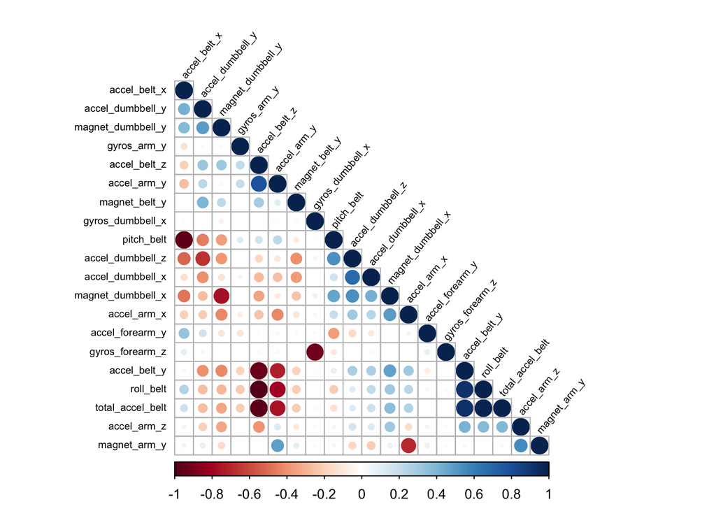

While these 20 highly-correlated features could be redundant, due to lack of interpretation of removing any of these featues, and which of the corrolated to keep, we opt to keep them all and let classifier training process feature selection and importance: we choose a wrapper vs a filter approach here.

We seed partitioning, and split our training data into a 60% traning and 40% cross-validation set, to later determine out-of-sample error rate.

## Model Training and Tuning

We choose to predict using a random forest classifier, to obtain high accuracy and accepting interpretation as less important given the remaining high number of features. We use cross-validation method for resampling. And we perform 5 folds with no perceived loss in accuracy.

The final model OOB error rate is 0.77%, which is quite low.

## Variable Importance

We explore variable importance, and do see reasonable use of predictors:

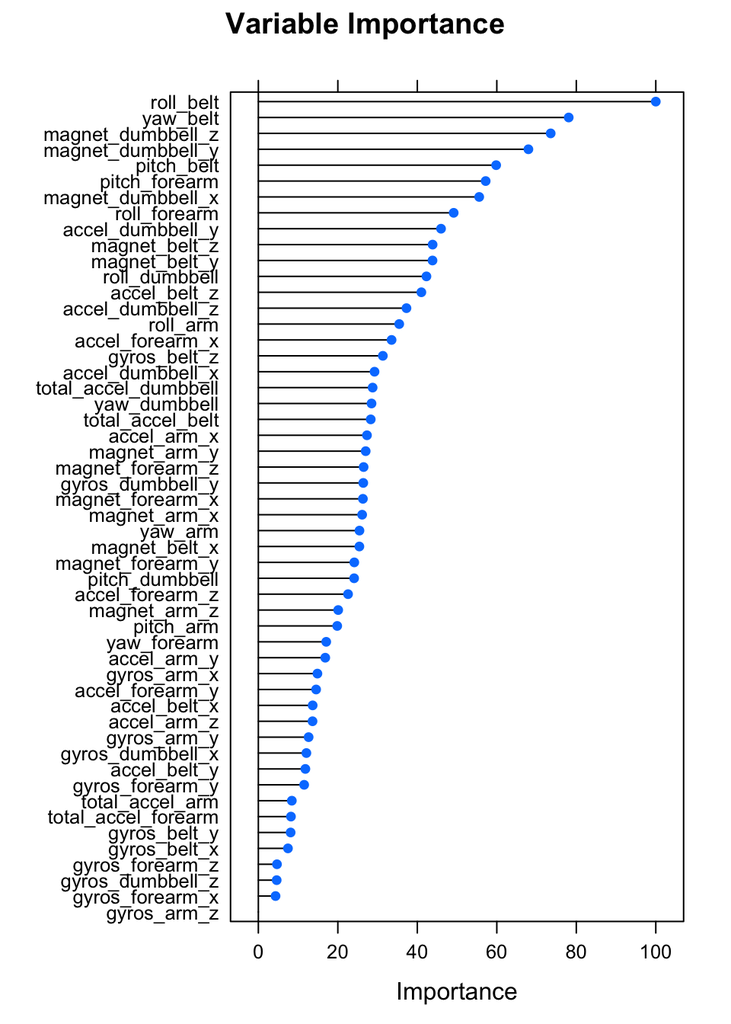

## Prediction and Results

We predict on the cross-validation set to get projected out-of-sample error rate.

Out-of-sample accuracy is 99.07%. The 95% confidence interval for that accuracy is 98.83% to 99.27%. Out-of-sample error is 0.93%.

Sensitivity (as a percentage) is high accross all classes (albeit a slight drop in class D):

```
## Class: A Class: B Class: C Class: D Class: E
##    99.87    98.81    99.27    97.36    99.45
```

Specificity (as a percentage) is also high accross all classes:

```
## Class: A Class: B Class: C Class: D Class: E
##    99.77    99.79    99.37    99.94    99.97
```

We use our final model against test data, which correctly predicted all classes:

```
##  [1] B A B A A E D B A A B C B A E E A B B B
## Levels: A B C D E
```

*[1] Velloso, E.; Bulling, A.; Gellersen, H.; Ugulino, W.; Fuks, H. Qualitative Activity Recognition of Weight Lifting Exercises. Proceedings of 4th International Conference in Cooperation with SIGCHI (Augmented Human ’13) . Stuttgart, Germany: ACM SIGCHI, 2013*